# PP1

Predicción de ganancias de unidades económicas

En este proyecto se utilizará el Censo Económico 2019 del INEGI como fuente principal de información. El objetivo central es predecir la ganancia de las unidades económicas a partir de diversos factores relacionados con sus actividades productivas, económicas y de personal.

La variable de ganancia se define como la diferencia entre los ingresos totales y los gastos totales. Para comprender mejor qué determina este resultado, se analizará el impacto de 184 variables sobre las ganancias, intentando acercarse a un modelo que lo simplifique a pocas variables que expliquen el fenómeno.

A través de modelos de regresión, se buscará capturar la relación entre dichas variables y generar predicciones que permitan identificar los factores más influyentes en la ganancia de las unidades. Este enfoque puede resultar valioso tanto para el diseño de políticas públicas como para la definición de estrategias comerciales en distintos sectores.

Las descripciones detalladas de cada variable empleada se encuentran en el documento PDF adjunto.

Empezamos este proyecto importando correctamente la base de datos del censo económico a nuestro espacio de trabajo. En este caso, se necesitaron pasos extra por el acomodo de la base de datos, al importarse, se tuvieron que eliminar tabulaciones y las columnas se importaban desplazadas, por lo que las desplazamos de vuelta a su lugar original.

```python
import pandas as pd #Importamos librería

with open('EncuestaNacional2019.csv', 'r', encoding='utf-8') as file: #Para asegurar que se pueda abrir base de datos
    lines = file.readlines()
lines = [line.lstrip('\t') for line in lines] #Se elimina tabulación de las líneas de datos
with open('archivo_limpio.csv', 'w', encoding='utf-8') as file: #Se copian las lineas limpias en nuevo archivo
    file.writelines(lines)
df = pd.read_csv('archivo_limpio.csv', sep=',', encoding='utf-8') #Leemos los datos
df = df.shift(periods=1, axis=1) #Desplazamos los datos una columna a la derecha
print(df.head(10)) # Verificar las primeras filas que todo esté en orden
```

```
 ENTIDAD MUNICIPIO CODIGO  ID_ESTRATO       UE         A111A         A121A  \
    None                          NaN  4800157  2.221225e+07  1.222845e+07
    None                          1.0  4555263  2.418236e+06  9.557533e+05
    None                          2.0   193423  2.222578e+06  1.024622e+06
    None                          3.0    40824  4.074467e+06  2.209040e+06
    None                          4.0    10647  1.349697e+07  8.039034e+06
    None               11         NaN    24372  4.459661e+04  2.470224e+04
    None               11         1.0    19729  6.790579e+03  3.733452e+03
    None               11         2.0     3768  1.456554e+04  8.067424e+03
    None               11         3.0      822  1.604545e+04  8.949206e+03
    None               11         4.0       53  7.195036e+03  3.952154e+03

        A131A       A211A       A221A  ...       A256A    A433A   A434A  \
  9983800.258  893956.138  746451.840  ...  175646.979  174.571  92.873
  1462482.828   23372.595   26762.926  ...   22304.316  177.960  95.629
  1197956.808   45210.637   53223.315  ...   92724.326  155.739  94.735
  1865426.903  149108.280  131416.861  ...  170315.011  156.565  93.157
  5457933.719  676264.626  535048.738  ...  394035.263  189.032  91.552
    19894.369     714.257     724.279  ...   61413.365  371.578  95.850
     3057.127     109.039     107.870  ...   51192.952  358.753  96.780
     6498.113     233.411     236.538  ...   52772.230  344.540  95.903
     7096.247     307.512     311.929  ...   70102.304  420.042  95.963
     3242.882      64.295      67.942  ...   87711.751  349.137  94.648

        A436A   A529A   A534A    A747A    A748A    A752A   A764A
  1084154.128   8.035  30.922  338.244  638.349   86.186  41.258
   400706.606   8.028  35.112  208.822  298.456  115.636  48.679
  1070439.090   7.968  28.274  222.793  353.402   86.056  39.195
  1577257.795   8.354  27.791  294.073  465.287  101.622  35.197
  1637641.829   7.967  32.014  386.634  713.805   76.963  36.617
   190602.593   9.804  46.671  229.125  447.895   74.811  13.778
   139983.482   7.653  50.151  209.208  362.580   48.394  12.032
   166583.544   9.060  45.413  191.544  428.949   70.512  14.537
   213250.203  11.238  45.514  224.761  457.296   86.773  12.765
   315951.871  12.823  48.646  206.813  306.992  112.515  17.917

[10 rows x 186 columns]
```

Por la naturaleza de las variables y la variable de salida, creo que una regresión lineal puede ser muy buena para predecir la salida de ganancia, ya que, revisando variables como ingresos, gastos, personas que trabajan, entre muchas otras, entre mayores sean, mayor actividad económica, es decir, una relación positiva, que, aunque no puedo ver en tipo scatter, puedo empezar asumiendo una forma lineal y evaluar su desempeño.

Antes de empezar con cualquier tipo de regresión o incluso análisis del dataframe, limpiaremos los datos.

```python
print("Dimensiones del df original:", df.shape)
columnas_no_numericas = df.select_dtypes(exclude=['number']).columns # Filtrar columnas no numéricas
print("Variables no numéricas en el DataFrame:") # Imprimir las columnas no numéricas
print(columnas_no_numericas.tolist())

df = df.drop('ENTIDAD', axis=1)  #Eliminamos columna entidad

df = df.drop('MUNICIPIO', axis=1) #Eliminamos columna municipio

df['Ganancia'] = df['A800A'] - df['A700A']
df = df.drop('A800A', axis=1)  #Eliminamos columna ingresos
df = df.drop('A700A', axis=1) #Eliminamos columna gastos
df = df.drop('UE', axis=1) #Eliminamos columna UE
df = df.drop('CODIGO', axis=1) #Eliminamos columna codigo

df['ID_ESTRATO'] = df['ID_ESTRATO'].fillna(99) #Llenamos NaNs con 99 porque significa que no hay información
dummies = pd.get_dummies(df['ID_ESTRATO'], prefix='ID_ESTRATO', drop_first=True).astype(int) #gGeneramos dummies (0-1)
df = pd.concat([df, dummies], axis=1) #Agregamos variables dummy a la base de datos
df = df.drop('ID_ESTRATO', axis=1)  #Eliminamos columna ID estrato

print(df.isna().sum()) #Imprimimos cuantos datos NaN hay en cada variable
df.fillna(df.mean(), inplace=True) #Llenamos los NaN por la media de la variable
print(df.isna().sum())  # Nuevo número de NaN por columna

print("Cantidad de observaciones del df original:", df.shape[0])
df = df.reset_index(drop=True) #reseteamos índice de los datos para evitar que no coincidan
import numpy as np #Importamos librería
q1=df.Ganancia.quantile(0.25) #Identificamos percentil .25
q3=df.Ganancia.quantile(0.75)#Identificamos percentil .75
li=q1-3*(q3-q1) #Definimos límite inferior con tukey
ls=q3+3*(q3-q1) #Definimos límite superior con tukey
out=np.where((df.Ganancia<=li) | (df.Ganancia>=ls))[0] #Encontramos los datos que están fuera del rango
df= df.drop(index=out).reset_index(drop=True) #Eliminamos del dataframe los outliers
print("Tamaño del df sin outliers:", df.shape[0]) #Imprimimos datos restantes
```

```
Dimensiones del df original: (7293, 186)
Variables no numéricas en el DataFrame:
['ENTIDAD', 'MUNICIPIO', 'CODIGO']
A111A              34
A121A              34
A131A              34
A211A              34
A221A              34
                   ..
Ganancia           34
ID_ESTRATO_2.0      0
ID_ESTRATO_3.0      0
ID_ESTRATO_4.0      0
ID_ESTRATO_99.0     0
Length: 184, dtype: int64
A111A              0
A121A              0
A131A              0
A211A              0
A221A              0
                  ..
Ganancia           0
ID_ESTRATO_2.0     0
ID_ESTRATO_3.0     0
ID_ESTRATO_4.0     0
ID_ESTRATO_99.0    0
Length: 184, dtype: int64
Cantidad de observaciones del df original: 7293
Tamaño del df sin outliers: 6617
```

Pasamos a analizar la colinealidad de los datos para evitar hacer una regresión que incluya datos que sean colineales, para eliminarlos y evitar que afecten la precisión de nuestro modelo.

```python
vars_ingresos = [
    "M000A","M010A","M020A","M030A","M050A","M090A","M091A","M700A",  # variables M
    "A223A","A224A","A225A","A235A","A253A","A434A","A436A"            # variables A relacionadas
]

# Gastos (K... y algunas A... relacionadas con gastos)
vars_gastos = [
    "K000A","K010A","K020A","K030A","K042A","K050A","K060A","K070A","K090A",
    "K096A","K311A","K412A","K610A","K620A","K810A","K820A","K910A","K950A","K976A",
    "A208A","A209A","A212A","A214A","A236A","A237A","A252A"             # variables A relacionadas
]

# --- Eliminar columnas del df ---
df = df.drop(columns=vars_ingresos + vars_gastos)

print("Variables restantes:", df.shape[1])
```

```
Variables restantes: 143
```

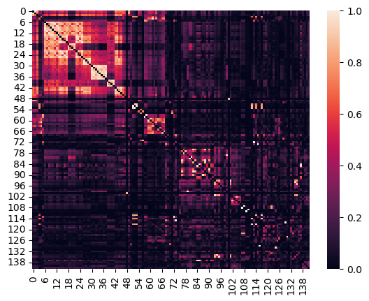

```python
dfCor=df.drop("Ganancia", axis=1) #Quitamos la variable de salida
cor=abs(np.corrcoef(dfCor,rowvar=False)) #Hacemos la matriz de correlaciones
np.fill_diagonal(cor,0) #Eliminamos los 1 de la diagonal
from seaborn import heatmap
heatmap(cor) #Generamos heatmap
```

El mapa es demasiado confuso por la cantidad de variables que tenemos, por lo tanto, nos apoyaremos con ciclos para eliminar las variables cuya correlación sea mayor a 0.9. Tambieneliminamos todas las variables relacionadas a ingresos o gastos, para que el modelo que obtengamos si sea util

```
Eliminada: A248A (correlación con A219A = 1.00)
Eliminada: A179A (correlación con A145A = 1.00)
Eliminada: A202A (correlación con A201A = 1.00)
Eliminada: A206A (correlación con A204A = 1.00)
Eliminada: H010B (correlación con H101B = 0.99)
Eliminada: A147A (correlación con A146A = 0.99)
Eliminada: Q000C (correlación con A221A = 0.99)
Eliminada: A116A (correlación con A216A = 0.99)
Eliminada: H010D (correlación con H101D = 0.99)
Eliminada: H101A (correlación con H010A = 0.99)
Eliminada: P000B (correlación con P000A = 0.99)
Eliminada: H001C (correlación con H000C = 0.99)
Eliminada: H203D (correlación con H203A = 0.99)
Eliminada: H101C (correlación con H010C = 0.99)
Eliminada: H001A (correlación con H000A = 0.99)
Eliminada: H001B (correlación con H000B = 0.99)
Eliminada: A747A (correlación con A173A = 0.99)
Eliminada: I200D (correlación con I200A = 0.99)
Eliminada: H001D (correlación con H000D = 0.98)
Eliminada: A117A (correlación con A218A = 0.98)
Eliminada: P100B (correlación con P100A = 0.98)
Eliminada: A182A (correlación con A171A = 0.98)
Eliminada: A152A (correlación con A151A = 0.98)
Eliminada: I100A (correlación con I100B = 0.97)
Eliminada: I000D (correlación con I000A = 0.97)
Eliminada: I000B (correlación con I100B = 0.97)
Eliminada: A748A (correlación con A174A = 0.97)
Eliminada: J010A (correlación con J000A = 0.97)
Eliminada: H203B (correlación con H203A = 0.97)
Eliminada: H101D (correlación con H010A = 0.97)
Eliminada: H020D (correlación con H020A = 0.97)
Eliminada: H000D (correlación con H000A = 0.97)
Eliminada: H203A (correlación con H203C = 0.97)
Eliminada: A157A (correlación con A154A = 0.97)
Eliminada: A121A (correlación con A111A = 0.96)
Eliminada: Q000A (correlación con Q000B = 0.96)
Eliminada: A222A (correlación con A217A = 0.96)
Eliminada: A155A (correlación con A148A = 0.96)
Eliminada: A764A (correlación con A151A = 0.95)
Eliminada: I000C (correlación con I100C = 0.95)
Eliminada: I100D (correlación con I100B = 0.95)
Eliminada: P000C (correlación con P000A = 0.94)
Eliminada: J300A (correlación con J000A = 0.94)
Eliminada: A256A (correlación con A242A = 0.94)
Eliminada: I200B (correlación con I200A = 0.94)
Eliminada: I000A (correlación con I100B = 0.93)
Eliminada: I200A (correlación con I200C = 0.93)
Eliminada: H020C (correlación con H020A = 0.92)
Eliminada: A141A (correlación con A148A = 0.92)
Eliminada: A194A (correlación con A192A = 0.92)
Eliminada: H000B (correlación con H000A = 0.91)
Eliminada: H101B (correlación con H010A = 0.91)
Eliminada: H000A (correlación con H000C = 0.90)

Total de variables eliminadas: 53
Columnas eliminadas: ['A248A', 'A179A', 'A202A', 'A206A', 'H010B', 'A147A', 'Q000C', 'A116A', 'H010D', 'H101A', 'P000B', 'H001C', 'H203D', 'H101C', 'H001A', 'H001B', 'A747A', 'I200D', 'H001D', 'A117A', 'P100B', 'A182A', 'A152A', 'I100A', 'I000D', 'I000B', 'A748A', 'J010A', 'H203B', 'H101D', 'H020D',…
```

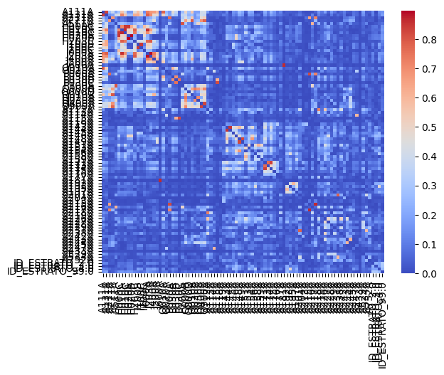

```python
dfCor = dfCor.reset_index(drop=True)
eliminadas = []
while True:
    cor = abs(np.corrcoef(dfCor, rowvar=False))
    np.fill_diagonal(cor, 0)
    i, j = np.unravel_index(cor.argmax(), cor.shape)
    if cor[i, j] <= 0.9:
        break

    col_a = dfCor.columns[i]
    col_b = dfCor.columns[j]
    dfCor = dfCor.drop(col_b, axis=1)
    df=df.drop(col_b, axis=1)
    eliminadas.append(col_b)
    print(f"Eliminada: {col_b} (correlación con {col_a} = {cor[i, j]:.2f})")
print(f"\nTotal de variables eliminadas: {len(eliminadas)}")
print("Columnas eliminadas:", eliminadas)
cor_final = abs(np.corrcoef(dfCor, rowvar=False))
np.fill_diagonal(cor_final, 0)
heatmap(cor_final, xticklabels=dfCor.columns, yticklabels=dfCor.columns, cmap="coolwarm")
```

Así nos deshicimos de muchas de las variables las cuales eran redundantes y entorpecerían nuestro modelo. Aunque nuestro heat map sigue siendo confuso pero nos ayuda a verificar índices de colinealidad.

Ya tenemos nuestros datos listos para empezar a trabajar con ellos. Primero dividimos nuestros datos en train y test para evitar la fuga de datos y verificamos que haya quedado correctamente.

```python
df = df.reset_index(drop=True) #Reiniciamos el índice del DataFrame para que quede ordenado y sin huecos

train=df.sample(frac=.7, random_state=42) #Seleccionamos aleatoriamente el 70% de los datos para entrenamiento
print(train.shape) #Imprimimos la forma del conjunto de entrenamiento

test = df.drop(train.index) #El conjunto de prueba será el 30% restante (los datos que no entraron en train)

x_train=train.drop("Ganancia", axis=1) #Definimos las variables independientes (X) para entrenamiento
y_train=train["Ganancia"] #Definimos la variable dependiente (y) para entrenamiento

x_test=test.drop("Ganancia", axis=1) #Definimos las variables independientes (X) para prueba
y_test=test["Ganancia"] #Definimos la variable dependiente (y) para prueba

print("Train:", train.shape[0]) #Mostramos la cantidad de observaciones en el set de entrenamiento
print("Test:", test.shape) #Mostramos la cantidad de observaciones en el set de prueba

total=train.shape[0]+test.shape[0] #Calculamos el total de registros para verificar consistencia
print("Total de datos: ", total) #Mostramos el total de datos del DataFrame
```

```
(4632, 90)
Train: 4632
Test: (1985, 90)
Total de datos:  6617
```

Ahora haremos un proceso de selección de características. Nuestro dataframe tiene demasiadas variables y nos gustaría simplificar el modelo lo más posible, perdiendo la menor precisión posible, por lo que realizaremos una metodología de selección combinada hacia delante y hacia atrás, que, aunque involucra dos pasos, nos ayudará a eliminar muchas variables. Primero haré la selección hacia delante, y pondré como máximo 8 variables.

```python
from mlxtend.feature_selection import SequentialFeatureSelector as SFS #Importamos función de la librería
from sklearn.linear_model import LinearRegression #importamos función para usar como estimator
sfs_1 = SFS(LinearRegression(), k_features=(1,8), forward=True,scoring='r2',cv=10) #Definimos los parámetros de la función de selección
sfs_1= sfs_1.fit(x_train, y_train) #Aplicamos sfs a nuestros datos de entrenamiento
print("Variables seleccionadas: ", sfs_1.k_feature_names_) #Imprimimos las variables seleccionadas
```

```
Variables seleccionadas:  ('A131A', 'H010A', 'H010C', 'O020A', 'Q010A', 'A119A', 'A242A', 'A244A')
```

Después el primer paso quedamos justo con 8 variables, que pueden ser muchas para trabajar todavía en algunos casos, por los que pasamos a la selección hacia atrás, poniendo como máximo 4 variables.

```python
lr=LinearRegression() #Nombremos la función lr
x_train_sfs = sfs_1.transform(x_train) #Quitamos variables no seleccionadas del train
x_test_sfs  = sfs_1.transform(x_test) #Quitamos variables no seleccionadas del test
sfs_2 = SFS(LinearRegression(), k_features=(1,4), forward=False,scoring='r2',cv=10) #Definimos los parámetros de la función de selección
sfs_2 = sfs_2.fit(x_train_sfs , y_train) #Aplicamos sfs a nuestros datos de entrenamiento ya ajustados
#Hacemos esto para que se muestren los nombres de las variables escogidas, ya que al usar SFS primero, cambia los nombres de columna a números.
selected_first = list(sfs_1.k_feature_names_) #Hacemos ista d elas variables seleccionadas en el primer paso
idx_second = sfs_2.k_feature_idx_ #Obtenemos los índices de las variables seleccionadas en el segundo paso
selected_final = [selected_first[i] for i in idx_second] #Construimos la lista final con las variables seleccionadas en ambos pasos
print("Variables seleccionadas: ", selected_final) #Mostramos en pantalla las variables seleccionadas definitivamente
```

```
Variables seleccionadas:  ['A131A', 'Q010A', 'A119A', 'A244A']
```

Obtuvimos 4 variables más significativas para nuestro modelo, que, al revisar nuestro diccionario, pueden quedar más claras.

```python
x_train= x_train[selected_final] #Filtramos las variables de entrenamiento para quedarnos solo con las seleccionadas
x_test = x_test[selected_final] #Filtramos las variables de prueba para quedarnos solo con las seleccionadas
print("Después de filtrar, x_train tiene dimensiones:", x_train.shape) #Mostramos cuántas columnas quedaron después del filtrado
x_train_sfs_2 = sfs_2.transform(x_train_sfs) #Aplicamos el transformador SFS para quitar variables no seleccionadas del train
x_test_sfs_2  = sfs_2.transform(x_test_sfs) #Aplicamos el transformador SFS para quitar variables no seleccionadas del test
```

```
Después de filtrar, x_train tiene dimensiones: (4632, 4)
```

```python
import statsmodels.api as sm #Importamos la librería statsmodels para análisis estadístico
modelo=sm.OLS(y_train, sm.add_constant(x_train)) #Definimos el modelo de regresión OLS (Mínimos Cuadrados Ordinarios) incluyendo la constante
resultados=modelo.fit() #Ajustamos el modelo a los datos de entrenamiento
print(resultados.summary()) #Mostramos un resumen completo del modelo (coeficientes, R², AIC, BIC, etc.)
print(resultados.params) #Mostramos únicamente los coeficientes estimados de cada variable
print("P values") #Mostramos los p-values para evaluar la significancia estadística de las variables
print(resultados.pvalues)
y_hat_l = resultados.predict(sm.add_constant(x_test))  # Añadimos la constante y hacemos la predicción
```

```
                            OLS Regression Results
==============================================================================
Dep. Variable:               Ganancia   R-squared:                       0.983
Model:                            OLS   Adj. R-squared:                  0.983
Method:                 Least Squares   F-statistic:                 6.823e+04
Date:                Sun, 07 Sep 2025   Prob (F-statistic):               0.00
Time:                        20:29:24   Log-Likelihood:                -36753.
No. Observations:                4632   AIC:                         7.352e+04
Df Residuals:                    4627   BIC:                         7.355e+04
Df Model:                           4
Covariance Type:            nonrobust
==============================================================================
                 coef    std err          t      P>|t|      [0.025      0.975]
------------------------------------------------------------------------------
const         13.7381     13.489      1.018      0.309     -12.707      40.183
A131A          0.9863      0.002    513.668      0.000       0.983       0.990
Q010A         -0.0455      0.001    -53.631      0.000      -0.047      -0.044
A119A        -14.1591      0.985    -14.374      0.000     -16.090     -12.228
A244A          0.8954      0.105      8.509      0.000       0.689       1.102
==============================================================================
Omnibus:                     4619.719   Durbin-Watson:                   1.991
Prob(Omnibus):                  0.000   Jarque-Bera (JB):           988582.945
Skew:                           4.349   Prob(JB):                         0.00
Kurtosis:                      74.039   Cond. No.                     1.71e+04
==============================================================================

Notes:
[1] Standard Errors assume that the covariance matrix of the errors is correctly specified.
[2] The condition number is large, 1.71e+04. This might indicate that there are
strong multicollinearity or other numerical problems.
const    13.738072
A131A     0.986316
Q010A    -0.045487
A119A   -14.159092
A244A     0.895443
dtype: float64
P values
const    3.085114e-01
A131A    0.000000e+00
Q010A    0.000000e+00
A119A    7.269837e-46
A244A    2.335626e-17
dtype: float64
```

Ahora queremos generar un modelo de regresión cuadrática, para ver si se ajusta mejor al modelo.

```python
from sklearn.preprocessing import StandardScaler,PolynomialFeatures #Importamos la librería para generar características polinomiales

# Reiniciamos índices
y_train = y_train.reset_index(drop=True)
x_train = x_train.reset_index(drop=True)
x_test = x_test.reset_index(drop=True)

# Generamos solo los términos polinomiales individuales (sin interacciones)
polyq = PolynomialFeatures(degree=2, interaction_only=False, include_bias=False)

Xq_train_full = pd.DataFrame(polyq.fit_transform(x_train),
                             columns=polyq.get_feature_names_out(x_train.columns))

Xq_test_full = pd.DataFrame(polyq.transform(x_test),
                            columns=polyq.get_feature_names_out(x_test.columns))

# Filtramos solo los términos cuadrados (ej: A131A^2, Q010A^2, ...) y los originales
# Excluimos las interacciones que tienen espacios en el nombre
Xq_train = Xq_train_full[[c for c in Xq_train_full.columns if " " not in c]]
Xq_test = Xq_test_full[[c for c in Xq_test_full.columns if " " not in c]]

# Ajustamos modelo OLS
Xq_train_const = sm.add_constant(Xq_train)
mq = sm.OLS(y_train, Xq_train).fit()

# Tabla de coeficientes
tabla_coef = pd.DataFrame({
    "Variable": mq.params.index,
    "Coeficiente": mq.params.values,
    "Límite inferior": mq.conf_int()[0].values,
    "Límite superior": mq.conf_int()[1].values,
    "p-value": mq.pvalues.values
}).sort_values(by="p-value").reset_index(drop=True)

print(tabla_coef)
```

```
  Variable   Coeficiente  Límite inferior  Límite superior       p-value
0    A131A  1.005548e+00     9.972563e-01     1.013839e+00  0.000000e+00
1  Q010A^2 -9.437615e-08    -1.040704e-07    -8.468195e-08  3.143010e-78
2    A119A -1.450360e+01    -1.634945e+01    -1.265775e+01  2.982489e-52
3  A131A^2 -2.187219e-06    -2.627476e-06    -1.746962e-06  3.331160e-22
4  A119A^2 -4.845125e-02    -5.851219e-02    -3.839031e-02  5.684858e-21
5    A244A  6.565850e-01     3.740162e-01     9.391538e-01  5.362656e-06
6  A244A^2 -2.283228e-04    -4.465930e-04    -1.005258e-05  4.034576e-02
7    Q010A  1.731033e-03    -3.343975e-03     6.806040e-03  5.037212e-01
```

En este modelo de regresión cuadrática, cada coeficiente refleja el efecto estimado sobre la ganancia al variar la variable correspondiente, manteniendo constantes las demás. Por ejemplo, podemos asegurar con un 95% de confianza que un aumento de una unidad en A131A incrementa la ganancia entre 0.997 y 1.013 unidades, mientras que un aumento en A119A reduce la ganancia entre 12.66 y 16.35 unidades. Los términos cuadrados, como Q010A², A131A², A119A² y A244A², indican efectos no lineales: un incremento en Q010A disminuye la ganancia entre aproximadamente 8.47×10⁻⁸ y 1.04×10⁻⁷, y un aumento en A119A² provoca un efecto negativo entre 0.038 y 0.059 unidades. Por otro lado, el coeficiente lineal de A244A es positivo, con un efecto entre 0.374 y 0.939 unidades, mostrando que esta variable tiene un impacto significativo en la ganancia, mientras que su término cuadrático (A244A²) refleja un efecto negativo pequeño pero significativo. Finalmente, el coeficiente lineal de Q010A presenta un intervalo de confianza que incluye al cero (entre –0.0033 y 0.0068), además de un p-value alto, lo que indica que no podemos asegurar un efecto significativo para esta variable. Todos los demás intervalos excluyen el cero, por lo que podemos afirmar que estos efectos son estadísticamente significativos con un 95% de confianza.

Calculamos la R2 y el RSE para regresión lineal y cuadrática, para así poder hablar de y comparar la calidad de nuestros modelos.

```python
from sklearn.metrics import r2_score
("Modelo lineal")
print("RSE: ")
print(np.sqrt(np.sum((y_test - y_hat_l)**2) / (len(y_test) - 1)))
print("R²:", r2_score(y_test, y_hat_l))
print("Modelo cuadrático")
y_hat_mq = mq.predict(Xq_test) #Calculamos y predecida del modelo cuadratico
RSS_mq = np.sum((y_test - y_hat_mq)**2) #Calculamos RSS con fórmula
RSE = np.sqrt(RSS_mq / (len(y_test) - 1)) #Calculamos RSE por fórmula
print("RSE:", RSE)
print("R²:", r2_score(y_test, y_hat_mq))
```

[output not shown]

Para entenderlo un poco mejor, compararemos en dos gráficas los resultados reales vs obtenidos.

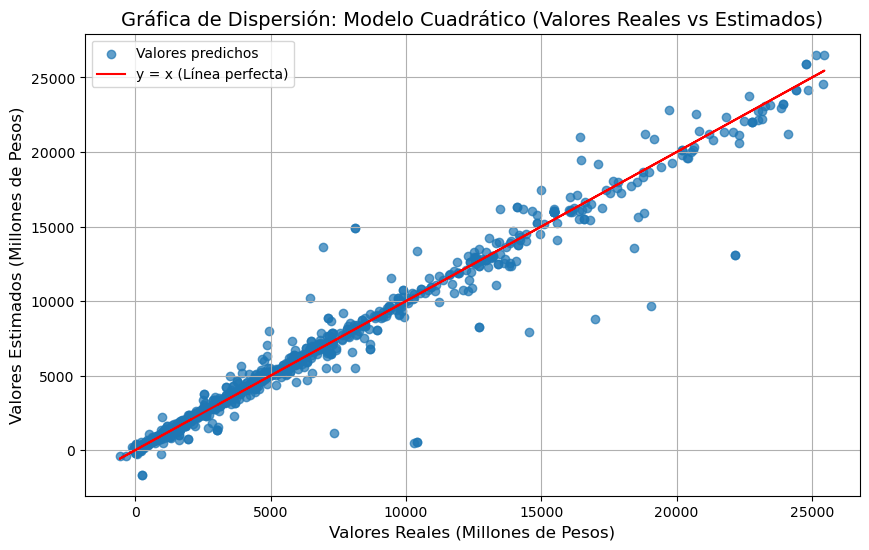

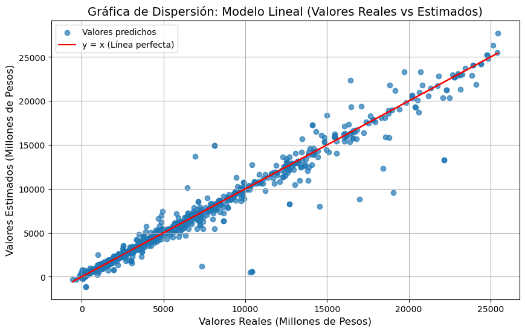

```python
%matplotlib inline
import matplotlib.pyplot as plt
# Gráfica de dispersión: valores reales vs estimados para el modelo cuadrático
plt.figure(figsize=(10, 6))
plt.scatter(y_test, y_hat_mq, alpha=0.7, label='Valores predichos')  # Graficamos valor real vs valor predicho
plt.plot(y_test, y_test, color='red', label='y = x (Línea perfecta)')  # Gráfico línea perfecta
plt.title('Gráfica de Dispersión: Modelo Cuadrático (Valores Reales vs Estimados)', fontsize=14)
plt.xlabel('Valores Reales (Millones de Pesos)', fontsize=12)
plt.ylabel('Valores Estimados (Millones de Pesos)', fontsize=12)
plt.legend(loc='best')
plt.grid(True)
plt.show()

# Gráfica de dispersión: valores reales vs estimados para el modelo lineal
plt.figure(figsize=(10, 6))
plt.scatter(y_test, y_hat_l, alpha=0.7, label='Valores predichos')  # Graficamos valor real vs valor predicho
plt.plot(y_test, y_test, color='red', label='y = x (Línea perfecta)')  # Gráfico línea perfecta
plt.title('Gráfica de Dispersión: Modelo Lineal (Valores Reales vs Estimados)', fontsize=14)
plt.xlabel('Valores Reales (Millones de Pesos)', fontsize=12)
plt.ylabel('Valores Estimados (Millones de Pesos)', fontsize=12)
plt.legend(loc='best')
plt.grid(True)
plt.show()
```

```python
mean_x_train=np.mean(x_train, axis=0)
mean_y_train=np.mean(y_train)


# Unimos conjuntos de entrenamiento y prueba para usar todos los datos para inferencia.
X = pd.concat([x_train, x_test], axis=0).copy()
y = pd.concat([y_train, y_test], axis=0).copy()
mean_X=np.mean(X, axis=0)
mean_y=np.mean(y)
print("Promedio x predicción")
print(mean_x_train)
print("Promedio x inferencia")
print(mean_X)
print("Promedio y predicción")
print(mean_y_train)
print("Promedio y inferencia")
print(mean_y)
# Reiniciamos índices
X = X.reset_index(drop=True)
y = y.reset_index(drop=True)

# Agregamos intercepto
X_const = sm.add_constant(X)  # Agrega columna 'const' para el intercepto

# Ajustamos modelo OLS
modelo = sm.OLS(y, X_const).fit()

# Resumen completo
print(modelo.summary())

# Tabla de inferencia con coeficientes, p-values e intervalos de confianza
tabla_inferencia = pd.DataFrame({
    "Variable": modelo.params.index,
    "Coeficiente": modelo.params.values,
    "Límite inferior": modelo.conf_int()[0].values,
    "Límite superior": modelo.conf_int()[1].values,
    "p-value": modelo.pvalues.values
}).sort_values(by="p-value").reset_index(drop=True)

print("\nTabla de inferencia con IC y p-values:")
print(tabla_inferencia)
```

```
Promedio x predicción
A131A    3616.325244
Q010A    1893.034774
A119A       1.680449
A244A      57.344991
dtype: float64
Promedio x inferencia
A131A    3595.952858
Q010A    1792.854061
A119A       1.815419
A244A      57.124634
dtype: float64
Promedio y predicción
3522.0244017242544
Promedio y inferencia
3509.920464909595
                            OLS Regression Results
==============================================================================
Dep. Variable:               Ganancia   R-squared:                       0.980
Model:                            OLS   Adj. R-squared:                  0.980
Method:                 Least Squares   F-statistic:                 8.288e+04
Date:                Sun, 07 Sep 2025   Prob (F-statistic):               0.00
Time:                        20:33:03   Log-Likelihood:                -52929.
No. Observations:                6617   AIC:                         1.059e+05
Df Residuals:                    6612   BIC:                         1.059e+05
Df Model:                           4
Covariance Type:            nonrobust
==============================================================================
                 coef    std err          t      P>|t|      [0.025      0.975]
------------------------------------------------------------------------------
const         20.2759     12.194      1.663      0.096      -3.629      44.181
A131A          0.9849      0.002    562.052      0.000       0.982       0.988
Q010A         -0.0442      0.001    -49.847      0.000      -0.046      -0.042
A119A        -14.8720      0.869    -17.114      0.000     -16.576     -13.169
A244A          0.9455      0.099      9.579      0.000       0.752       1.139
==============================================================================
Omnibus:                     6816.225   Durbin-Watson:                   1.784
Prob(Omnibus):                  0.000   Jarque-Bera (JB):          1560412.777
Skew:                           4.616   Prob(JB):                         0.00
Kurtosis:                      77.662   Cond. No.                     1.51e+04
==============================================================================

Notes:
[1] Standard Errors assume that the covariance matrix of the errors is correctly specified.
[2] The condition number is large, 1.51e+04. This might indicate that there are
strong multicollinearity or other numerical problems.

Tabla de inferencia con IC y p-values:
  Variable  Coeficiente  Límite inferior  Límite superior       p-value
0    A131A     0.984938         0.981503         0.988373  0.000000e+00
1    Q010A    -0.044153        -0.045889        -0.042416  0.000000e+00
2    A119A   -14.872033       -16.575501       -13.168565  2.762813e-64
3    A244A     0.945526         0.752023         1.139028  1.354341e-21
4    const    20.275888        -3.628769        44.180546  9.641141e-02
```

Análisis de Inferencia con Margen de Error (95% de Confianza):

A131A: Con un coeficiente de 0.9849 y un intervalo de confianza del 95% entre 0.982 y 0.988, podemos asegurar con un 95% de confianza que el verdadero valor del coeficiente está dentro de este rango. Esto indica que A131A tiene un efecto positivo y significativo sobre la ganancia, y cada unidad de aumento en A131A se asocia con un incremento de aproximadamente 0.985 unidades en la ganancia. El margen de error es de ±0.003.

Q010A: El coeficiente de -0.0442 para Q010A tiene un intervalo de confianza del 95% entre -0.046 y -0.042, lo que implica que, con un 95% de confianza, el verdadero valor del coeficiente se encuentra dentro de este rango. Esto confirma que Q010A tiene un efecto negativo significativo sobre la ganancia, y un aumento de 1 unidad en Q010A reduce la ganancia en aproximadamente 0.044 unidades. El margen de error es de ±0.002.

A119A: Con un coeficiente de -14.872 y un intervalo de confianza entre -16.576 y -13.169, podemos estar 95% seguros de que el verdadero valor de este coeficiente está dentro de ese rango. Esto significa que A119A tiene un fuerte impacto negativo en la ganancia, y un incremento de 1 unidad en A119A se asocia con una disminución de 14.872 unidades en la ganancia. El margen de error es de ±1.704.

A244A: El coeficiente de 0.9455 para A244A tiene un intervalo de confianza del 95% entre 0.752 y 1.139, lo que indica que, con un 95% de confianza, el verdadero valor del coeficiente está dentro de este rango. Esto sugiere que A244A tiene un efecto positivo sobre la ganancia, y un aumento de 1 unidad en A244A incrementa la ganancia en aproximadamente 0.946 unidades. El margen de error es de ±0.194.

En términos prácticos, una inferencia sencilla es que las unidades económicas con ganancias altas tienden a mostrar valores elevados en el Valor agregado censal bruto y en los Activos fijos a producción bruta total, manteniendo al mismo tiempo valores bajos en el Acervo total de maquinaria y equipo de producción y en la Participación de otros componentes de la producción bruta total. Por el contrario, las unidades con ganancias bajas se caracterizan por el patrón inverso. Como recomendación aplicada, las unidades económicas con desempeño limitado deberían fomentar estrategias que impulsen el Valor agregado censal bruto y los Activos fijos a producción bruta total, al tiempo que controlan o reducen los efectos negativos del Acervo de maquinaria y de la Participación de otros componentes de la producción bruta total.